# EP10 Grupo 1

2024-12-15

En esta tarea nos pidió realizar los siguientes pasos:

1.-Definir la semilla a utilizar, que corresponde a los últimos cuatro dígitos del RUN (sin considerar el dígito verificador) del integrante de mayor edad del equipo.

2.-Seleccionar una muestra de 150 mujeres (si la semilla es un número par) o 150 hombres (si la semilla es impar), asegurando que la mitad tenga estado nutricional “sobrepeso” y la otra mitad “no sobrepeso” en cada caso. Dividir esta muestra en dos conjuntos: los datos de 100 personas (50 con EN “sobrepeso”) para utilizar en la construcción de los modelos y 50 personas (25 con EN “sobrepeso”) para poder evaluarlos.

3.-Recordar las ocho posibles variables predictoras seleccionadas de forma aleatoria en el ejercicio anterior.

4.-Seleccionar, de las otras variables, una que el equipo considere que podría ser útil para predecir la clase EN, justificando bien esta selección (idealmente con literatura).

5.-Usando el entorno R, construir un modelo de regresión logística con el predictor seleccionado en el paso anterior y utilizando de la muestra obtenida.

6.-Usando estas herramientas para la exploración de modelos del entorno R1, buscar entre dos y cinco predictores de entre las variables seleccionadas al azar, recordadas en el punto 3, para agregar al modelo obtenido en el paso 5.

7.-Evaluar la confiabilidad de los modelos (i.e. que tengan un buen nivel de ajuste y sean generalizables) y “arreglarlos” en caso de que tengan algún problema.

8.-Usando código estándar, evaluar el poder predictivo de los modelos con los datos de las 50 personas que no se incluyeron en su construcción en términos de sensibilidad y especificidad.

```r
# Leo los datos
datos <- read.csv2(file = "EP09 Datos.csv", stringsAsFactors = TRUE)
```

A continuación se realizarón los pasos 1 y 2, es decir, se escogio la semilla y se filtraron los datos para obtener la muestra de 150 hombres, asegurando que la mitad tenga estado nutricional “sobrepeso” y la otra mitad “no sobrepeso” en cada caso. Posteriormente se dividió la muestra en dos conjuntos: los datos de 100 personas (50 con EN [estado nutricional] “sobrepeso”) para utilizar en la construcción de los modelos y 50 personas (25 con EN [estado nutricional] “sobrepeso”) para poder evaluarlos a futuro:

```r
# Semilla a utilizar
set.seed(8365)

# Filtro los datos
datos_filtrados = datos %>% filter(Gender == 1) %>% select(-Gender) %>% mutate(IMC = Weight / ((Height/100) ^2)) %>% mutate(EN = ifelse(IMC > 23.2, 0, 1))

datos_filtrados[["EN"]] <- factor(datos_filtrados[["EN"]])

muestraConSobrepeso <- datos_filtrados %>% filter(EN == 1) %>% sample_n(75)
muestraSinSobrepeso <- datos_filtrados %>% filter(EN == 0) %>% sample_n(75)

i_train <- sample(1:75, 50)

muestraEntrenamiento <- rbind(muestraConSobrepeso[i_train, ], muestraSinSobrepeso[i_train, ])
muestraTest <- rbind(muestraConSobrepeso[-i_train, ], muestraSinSobrepeso[-i_train, ])
```

A continuación se presentan las ocho variables predictoras seleccionadas en el capítulo anterior:

```r
nombre_respuesta <- "EN"
variables_seleccionadas <- c("Knee.Girth", "Biacromial.diameter", "Ankles.diameter", "Bitrochanteric.diameter", "Forearm.Girth", "Navel.Girth", "Calf.Maximum.Girth", "Wrist.Minimum.Girth")

print(variables_seleccionadas)
```

```
## [1] "Knee.Girth"              "Biacromial.diameter"
## [3] "Ankles.diameter"         "Bitrochanteric.diameter"
## [5] "Forearm.Girth"           "Navel.Girth"
## [7] "Calf.Maximum.Girth"      "Wrist.Minimum.Girth"
```

## Regresión Logística Simple

Se nos pide seleccionar una variable fuera de las ocho seleccionadas en el capítulo anterior, es por esto, que una vez realizando una pequeña investigación en la literatura, escogimos usar la variable Waist.Girth ya que la circunferencia de la cintura permite evaluar directamente el riesgo asociado a la grasa abdominal. Es por lo anteriorque se realizo el modelo de regresión logística simple con la variable ya mencionada.

```r
predictor <- "Waist.Girth"

modeloRLogitS <- glm(EN ~ Waist.Girth, family = binomial(link = "logit"), data = muestraEntrenamiento)

cat("Modelo de regresión logística simple\n")
```

```
## Modelo de regresión logística simple
```

```r
print(summary(modeloRLogitS))
```

```
##
## Call:
## glm(formula = EN ~ Waist.Girth, family = binomial(link = "logit"),
##     data = muestraEntrenamiento)
##
## Coefficients:
##             Estimate Std. Error z value Pr(>|z|)
## (Intercept) 22.54836    4.53494   4.972 6.62e-07 ***
## Waist.Girth -0.27564    0.05555  -4.962 6.97e-07 ***
## ---
## Signif. codes:  0 '***' 0.001 '**' 0.01 '*' 0.05 '.' 0.1 ' ' 1
##
## (Dispersion parameter for binomial family taken to be 1)
##
##     Null deviance: 138.629  on 99  degrees of freedom
## Residual deviance:  87.539  on 98  degrees of freedom
## AIC: 91.539
##
## Number of Fisher Scoring iterations: 5
```

## Regresión Logística Múltiple

Se nos solicita buscar entre dos y cinco predictores de entre las variables seleccionadas al azar, recordadas en el punto 3, para agregar al modelo obtenido en el paso 5. Es por esto que se realizo el modelo de regresión logística múltiple con algunas de las variables seleccionadas al azar, tal y como se muestra a continuación:

```r
predictores <- c("Knee.Girth", "Biacromial.diameter", "Ankles.diameter", "Bitrochanteric.diameter", "Forearm.Girth", "Navel.Girth", "Calf.Maximum.Girth", "Wrist.Minimum.Girth", "EN", "Waist.Girth")

muestraEntrenamiento_predictores <- muestraEntrenamiento %>% select(all_of(predictores)) %>% slice(sample(n()))

cota_inf <- glm(EN ~ Waist.Girth, family = binomial(link = "logit"),muestraEntrenamiento)

# Definir modelos inicial y máximo.
max <- glm(EN ~ ., family = binomial(link = "logit"), data = muestraEntrenamiento_predictores)

# Revisar un paso hacia adelante.
cat("\nIteración número 1:\n")
```

```
##
## Iteración número 1:
```

```r
cat("------\n")
print(add1(cota_inf, scope = max))
```

```
## Single term additions
##
## Model:
## EN ~ Waist.Girth
##                         Df Deviance    AIC
## <none>                       87.539 91.539
## Knee.Girth               1   85.278 91.278
## Biacromial.diameter      1   87.338 93.338
## Ankles.diameter          1   87.459 93.459
## Bitrochanteric.diameter  1   87.437 93.437
## Forearm.Girth            1   69.284 75.284
## Navel.Girth              1   87.383 93.383
## Calf.Maximum.Girth       1   76.093 82.093
## Wrist.Minimum.Girth      1   77.852 83.852
```

```r
# actualizar el modelo
modelo1 <- update(cota_inf, . ~ . + Forearm.Girth)

cat("\nIteración número 2:\n")
```

```
##
## Iteración número 2:
```

```r
cat("------\n")
print(add1(modelo1, scope = max))
```

```
## Single term additions
##
## Model:
## EN ~ Waist.Girth + Forearm.Girth
##                         Df Deviance    AIC
## <none>                       69.284 75.284
## Knee.Girth               1   69.282 77.282
## Biacromial.diameter      1   68.072 76.072
## Ankles.diameter          1   68.778 76.778
## Bitrochanteric.diameter  1   68.634 76.634
## Navel.Girth              1   68.757 76.757
## Calf.Maximum.Girth       1   64.766 72.766
## Wrist.Minimum.Girth      1   69.169 77.169
```

```r
# actualizar el modelo
modelo2 <- update(modelo1, . ~ . + Biacromial.diameter)

cat("\nIteración número 3:\n")
```

```
##
## Iteración número 3:
```

```r
cat("------\n")
print(add1(modelo2, scope = max))
```

```
## Single term additions
##
## Model:
## EN ~ Waist.Girth + Forearm.Girth + Biacromial.diameter
##                         Df Deviance    AIC
## <none>                       68.072 76.072
## Knee.Girth               1   67.976 77.976
## Ankles.diameter          1   67.834 77.834
## Bitrochanteric.diameter  1   67.955 77.955
## Navel.Girth              1   67.767 77.767
## Calf.Maximum.Girth       1   62.608 72.608
## Wrist.Minimum.Girth      1   67.752 77.752
```

```r
# actualizar el modelo
modelo3 <- update(modelo2, . ~ . + Calf.Maximum.Girth )

cat("\nIteración número 4:\n")
```

```
##
## Iteración número 4:
```

```r
cat("------\n")
print(add1(modelo3, scope = max))
```

```
## Single term additions
##
## Model:
## EN ~ Waist.Girth + Forearm.Girth + Biacromial.diameter + Calf.Maximum.Girth
##                         Df Deviance    AIC
## <none>                       62.608 72.608
## Knee.Girth               1   61.287 73.287
## Ankles.diameter          1   61.591 73.591
## Bitrochanteric.diameter  1   62.018 74.018
## Navel.Girth              1   62.427 74.427
## Wrist.Minimum.Girth      1   62.603 74.603
```

Como ya no hay más variables predictoras que mejoren el modelo usando la regresión paso a paso hacia adelante, se procede a mostrar el modelo obtenido (modelo3):

```r
cat("\nModelo de regresión logística múltiple\n")
```

```
##
## Modelo de regresión logística múltiple
```

```r
seleccion <- c("Forearm.Girth", "Biacromial.diameter", "Calf.Maximum.Girth")
modeloRLogitM <- glm(EN ~ Waist.Girth + Forearm.Girth + Biacromial.diameter + Calf.Maximum.Girth, family = binomial(link = "logit"), data = muestraEntrenamiento)

print(summary(modeloRLogitM))
```

```
##
## Call:
## glm(formula = EN ~ Waist.Girth + Forearm.Girth + Biacromial.diameter +
##     Calf.Maximum.Girth, family = binomial(link = "logit"), data = muestraEntrenamiento)
##
## Coefficients:
##                     Estimate Std. Error z value Pr(>|z|)
## (Intercept)         46.42699   10.66787   4.352 1.35e-05 ***
## Waist.Girth         -0.24709    0.06683  -3.697 0.000218 ***
## Forearm.Girth       -0.77295    0.24983  -3.094 0.001975 **
## Biacromial.diameter  0.23786    0.16686   1.426 0.153994
## Calf.Maximum.Girth  -0.39674    0.18407  -2.155 0.031136 *
## ---
## Signif. codes:  0 '***' 0.001 '**' 0.01 '*' 0.05 '.' 0.1 ' ' 1
##
## (Dispersion parameter for binomial family taken to be 1)
##
##     Null deviance: 138.629  on 99  degrees of freedom
## Residual deviance:  62.608  on 95  degrees of freedom
## AIC: 72.608
##
## Number of Fisher Scoring iterations: 6
```

## Confiabilidad de los modelos

A continuación se cumplirá con la instrucción 7, la cual consiste en evaluar la confiabilidad de los modelos (i.e. que tengan un buen nivel de ajuste y sean generalizables) y “arreglarlos” en caso de que tengan algún problema.

### Confiabilidad del Modelo de Regresión Logística Simple

Primero, comenzaremos evaluando la confiabilidad del modelo de regresión logística simple:

#### Bondad de Ajuste

```r
# Bondad de ajuste
cat("Bondad de ajuste del modelo univariado:\n")
```

```
## Bondad de ajuste del modelo univariado:
```

```r
rlogits_lrt <- anova(modeloRLogitS, test = "LRT")
print(rlogits_lrt)
```

```
## Analysis of Deviance Table
##
## Model: binomial, link: logit
##
## Response: EN
##
## Terms added sequentially (first to last)
##
##
##             Df Deviance Resid. Df Resid. Dev Pr(>Chi)
## NULL                           99    138.629
## Waist.Girth  1   51.091        98     87.539 8.82e-13 ***
## ---
## Signif. codes:  0 '***' 0.001 '**' 0.01 '*' 0.05 '.' 0.1 ' ' 1
```

#### Prueba de curvatura

```r
cat("\nPrueba de curvatura para el predictor del modelo de RLogitS:\n")
```

```
##
## Prueba de curvatura para el predictor del modelo de RLogitS:
```

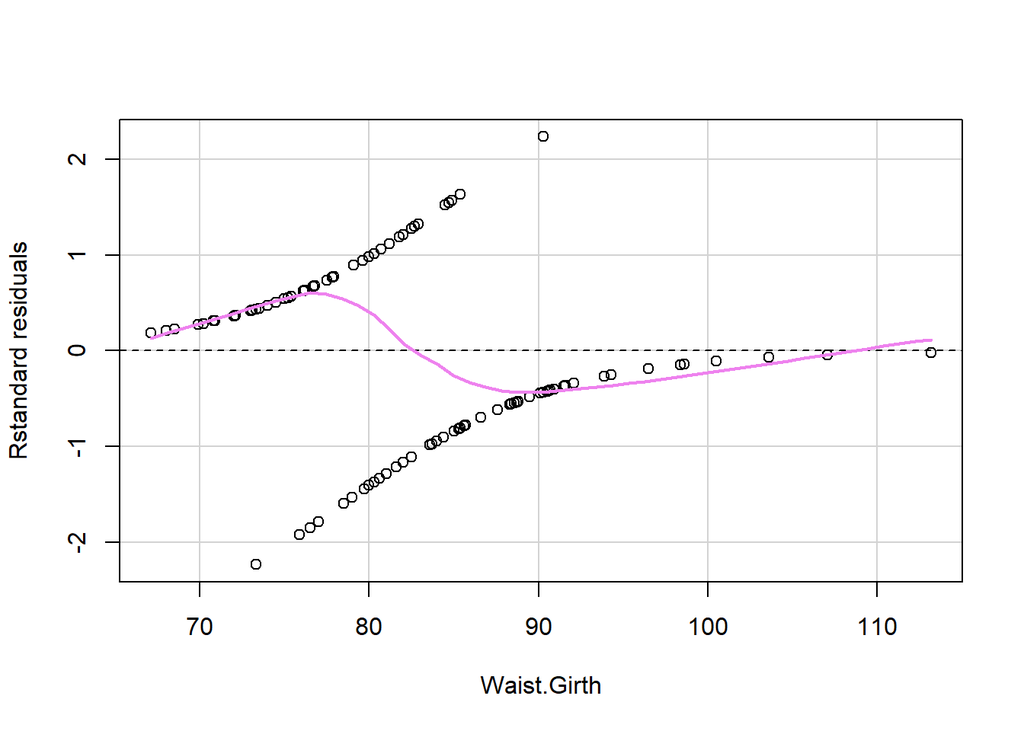

```
##             Test stat Pr(>|Test stat|)
## Waist.Girth    0.0709             0.79
```

```r
residualPlots(modeloRLogitS, type = "rstandard", fitted = FALSE, smooth = list(col = "violet"))
```

#### Relaciones lineales

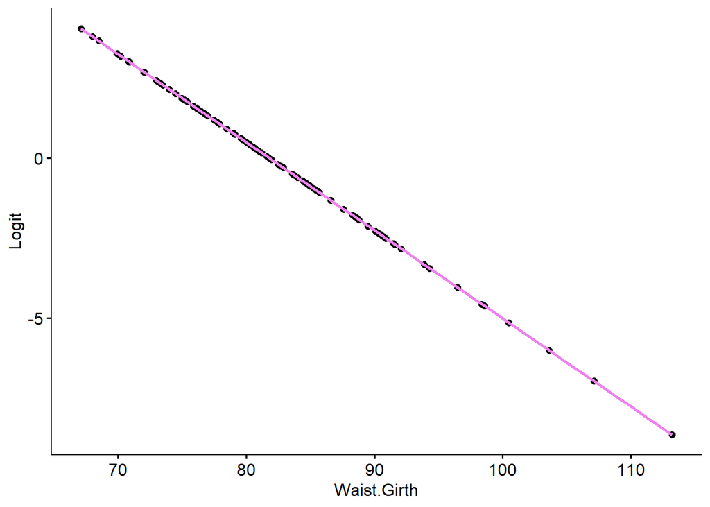

```r
# Modelo simple
rlogits_lin_df <- data.frame(
  muestraEntrenamiento[[predictor]],
  log(fitted(modeloRLogitS) / (1 - fitted(modeloRLogitS)))
)
colnames(rlogits_lin_df) <- c(predictor, "Logit")

p_rlogits_lin <- ggscatter(rlogits_lin_df, x = predictor, y = "Logit",
                           add = "reg.line", add.params = list(color = "violet"))
print(p_rlogits_lin)
```

Podemos ver que la relación entre la variable predictora y el logit de la probabilidad es lineal, lo que sugiere que no hay problemas de relación lineal en el modelo.

#### Diagnóstico de casos influyentes

```r
cat("\nCasos notorios para el modelo de regresión logistica simple:\n")
```

```
##
## Casos notorios para el modelo de regresión logistica simple:
```

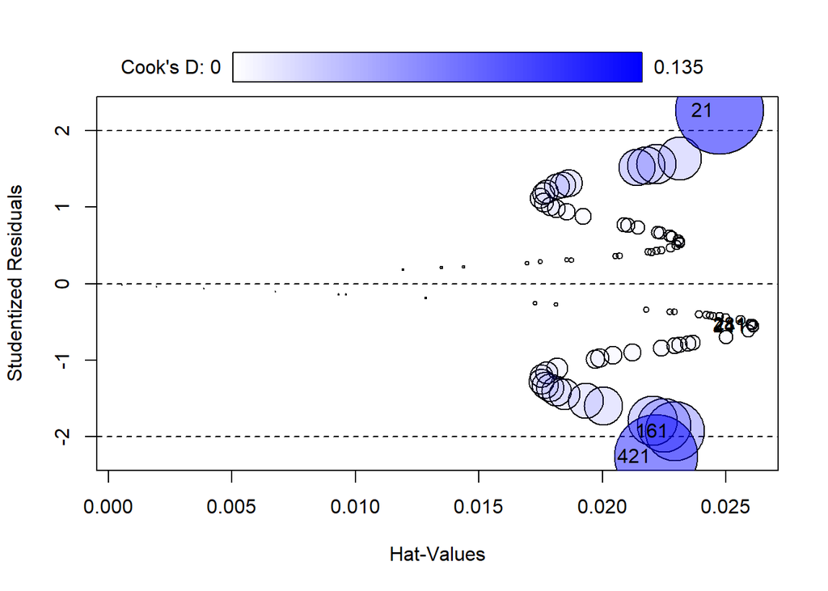

```r
rlogits_inf_estad <- influencePlot(modeloRLogitS, id = list(n = 3))
```

```r
print(rlogits_inf_estad)
```

```
##        StudRes        Hat       CookD
## 21   2.2650855 0.02474472 0.135253213
## 281 -0.5385137 0.02606255 0.002111035
## 241 -0.5525177 0.02609012 0.002233164
## 421 -2.2601275 0.02218255 0.120936248
## 161 -1.9321554 0.02291544 0.061106273
## 411 -0.5596343 0.02609287 0.002295829
```

Como se puede ver, no hay casos influyentes en el modelo de regresión logística simple.

#### Independencia de los residuos

```r
cat("Prueba de la independencia de los residuos para el modelo de RLogitS:\n")
```

```
## Prueba de la independencia de los residuos para el modelo de RLogitS:
```

```r
print(durbinWatsonTest(modeloRLogitS))
```

```
##  lag Autocorrelation D-W Statistic p-value
##    1       0.7043247     0.5834737       0
##  Alternative hypothesis: rho != 0
```

### Confiabilidad del Modelo de Regresión Logística Múltiple

#### Bondad de Ajuste

```r
# Bondad de ajuste
cat("Bondad de ajuste del modelo multivariado:\n")
```

```
## Bondad de ajuste del modelo multivariado:
```

```r
rlogitm_lrt <- anova(modeloRLogitS, modeloRLogitM, test = "LRT")
print(rlogitm_lrt)
```

```
## Analysis of Deviance Table
##
## Model 1: EN ~ Waist.Girth
## Model 2: EN ~ Waist.Girth + Forearm.Girth + Biacromial.diameter + Calf.Maximum.Girth
##   Resid. Df Resid. Dev Df Deviance  Pr(>Chi)
## 1        98     87.539
## 2        95     62.608  3   24.931 1.596e-05 ***
## ---
## Signif. codes:  0 '***' 0.001 '**' 0.01 '*' 0.05 '.' 0.1 ' ' 1
```

#### Prueba de curvatura

```r
cat("\nPrueba de curvatura para el predictor del modelo de RLogitM:\n")
```

```
##
## Prueba de curvatura para el predictor del modelo de RLogitM:
```

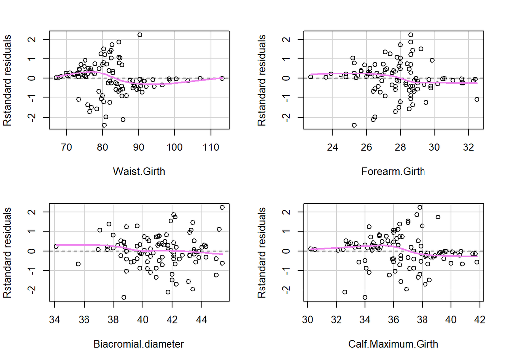

```
##                     Test stat Pr(>|Test stat|)
## Waist.Girth            0.1050           0.7459
## Forearm.Girth          0.8619           0.3532
## Biacromial.diameter    0.9638           0.3262
## Calf.Maximum.Girth     2.2147           0.1367
```

```r
residualPlots(modeloRLogitM, type = "rstandard", fitted = FALSE, smooth = list(col = "violet"))
```

Notemos que claramente las desviaciones de las medias no son significativas, por lo que el ajuste del modelo parece correcto.

#### Relaciones lineales

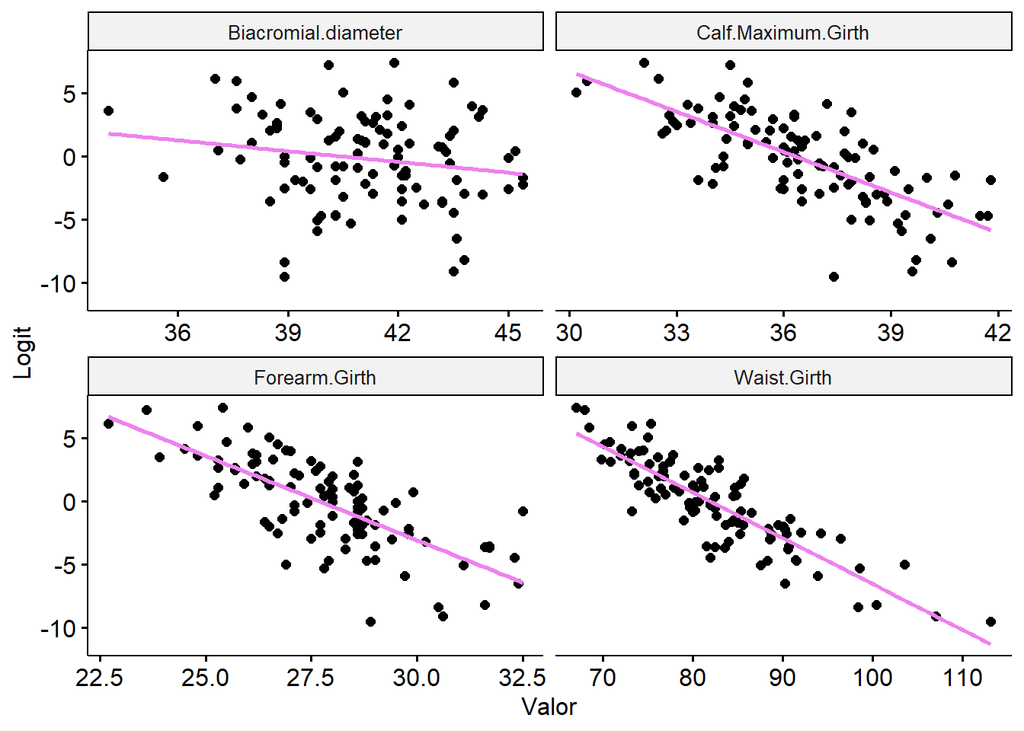

```r
rlogitm_lin_df <- muestraEntrenamiento[, c(predictor, seleccion)]
rlogitm_lin_df[["Logit"]] <- log(fitted(modeloRLogitM) / (1 - fitted(modeloRLogitM)))
rlogitm_lin_dfl <- pivot_longer(rlogitm_lin_df, -Logit, names_to = "Predictor", values_to = "Valor")

p_rlogitm_lin <- ggscatter(data = rlogitm_lin_dfl, x = "Valor", y = "Logit",
                           add = "reg.line", add.params = list(color = "violet")) +
                 facet_wrap(~ Predictor, scales = "free_x")
print(p_rlogitm_lin)
```

Claramente el modelo logra establecer relaciones lineales con los predictores, aunque se pueden generar un poco de dudas con el Biacromial.diameter.

#### Diagnóstico de casos influyentes

```r
cat("\nCasos notorios para el modelo de regresión logística múltiple:\n")
```

```
##
## Casos notorios para el modelo de regresión logística múltiple:
```

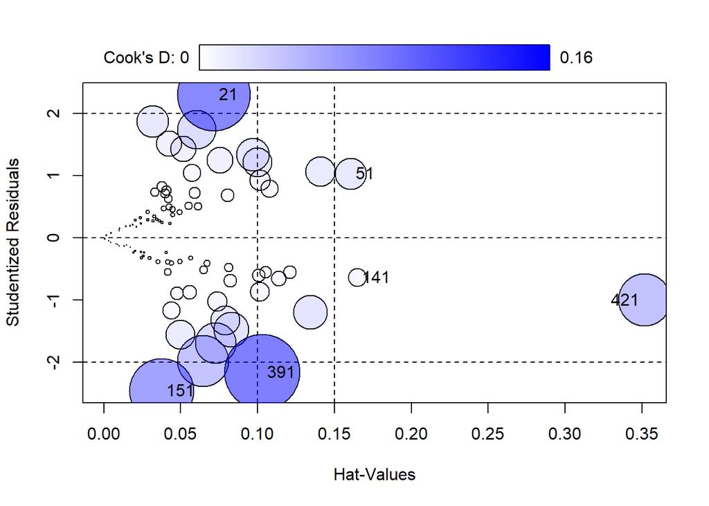

```r
rlogitm_inf_estad <- influencePlot(modeloRLogitM, id = list(n = 3))
```

```r
print(rlogitm_inf_estad)
```

```
##        StudRes        Hat       CookD
## 51   1.0262340 0.16059562 0.027298988
## 21   2.2976441 0.07152952 0.148198670
## 151 -2.4575322 0.03737834 0.116726720
## 391 -2.1621191 0.10298685 0.159675394
## 421 -1.0015745 0.35174987 0.076717274
## 141 -0.6383731 0.16469333 0.009528862
```

Como se puede ver, no hay casos influyentes en el modelo de regresión logística múltiple.

#### Independencia de los residuos

```r
cat("Prueba de la independencia de los residuos para el modelo de RLogitM:\n")
```

```
## Prueba de la independencia de los residuos para el modelo de RLogitM:
```

```r
print(durbinWatsonTest(modeloRLogitM))
```

```
##  lag Autocorrelation D-W Statistic p-value
##    1       0.5726198     0.8461467       0
##  Alternative hypothesis: rho != 0
```

#### Multicolinealidad

```r
cat("Multicolinealidad para el modelo de RLogitM:\n")
```

```
## Multicolinealidad para el modelo de RLogitM:
```

```r
print(vif(modeloRLogitM))
```

```
##         Waist.Girth       Forearm.Girth Biacromial.diameter  Calf.Maximum.Girth
##            1.061432            1.219042            1.254182            1.082578
```

Notemos que todos los valores obtenidos son menores a 3, lo que sugiere que no hay problemas de multicolinealidad en el modelo.

## Poder predictivo de los modelos

Antes de obtener el poder predictivo de los modelos, definiremos ciertas funciones que nos permitirán evaluar el rendimiento de los modelos.

```r
# Calcular metricas de rendimiento
metricas <- function(matriz) {
  exactitud <- sum(diag(matriz)) / sum(matriz)
  sensibilidad <- matriz[2, 2] / sum(matriz[, 2])
  especificidad <- matriz[1, 1] / sum(matriz[, 1])
  cat(sprintf("Exactitud: %.2f\nSensibilidad: %.2f\nEspecificidad: %.2f\n", exactitud,sensibilidad,especificidad))
  list(exactitud = exactitud, sensibilidad = sensibilidad, especificidad = especificidad)
}

# Comparar cambios entre entrenamiento y prueba
metricasDif <- function(entrenamiento, prueba) {
  cambio <- (entrenamiento - prueba) / prueba * 100
  return(cambio)
}
```

### Poder predictivo del modelo de regresión logística simple

```r
# Umbral incial
umbral <- 0.5

# Prediccion conjunto de entrenamiento
probabilidadesEntrenamiento <- predict(modeloRLogitS, muestraEntrenamiento, type = "response")
prediccionEntrenamiento <- ifelse(probabilidadesEntrenamiento >= umbral, 1, 0)

# Prediccion conjunto de prueba
probabilidadesTest <- predict(modeloRLogitS, muestraTest, type = "response")
prediccionPrueba <- ifelse(probabilidadesTest >= umbral, 1, 0)

# Matrices de confusión
matrizEntrenamiento <- table(Predicho = prediccionEntrenamiento, Observado = muestraEntrenamiento$EN)
matrizPrueba <- table(Predicho = prediccionPrueba, Observado = muestraTest$EN)

# Mostrar las matrices de confusión
cat("Matriz de confusión entrenamiento:\n")
```

```
## Matriz de confusión entrenamiento:
```

```r
print(matrizEntrenamiento)
```

```
##         Observado
## Predicho  0  1
##        0 38 12
##        1 12 38
```

```r
cat("\nMatriz de confusión prueba:\n")
```

```
##
## Matriz de confusión prueba:
```

```r
print(matrizPrueba)
```

```
##         Observado
## Predicho  0  1
##        0 18  1
##        1  7 24
```

```r
# Obtener métricas
cat("\nRendimiento del modelo simple de entrenamiento:\n")
```

```
##
## Rendimiento del modelo simple de entrenamiento:
```

```r
metricasEntrenamiento <- metricas(matrizEntrenamiento)
```

```
## Exactitud: 0.76
## Sensibilidad: 0.76
## Especificidad: 0.76
```

```r
cat("\nRendimiento del modelo simple de prueba:\n")
```

```
##
## Rendimiento del modelo simple de prueba:
```

```r
metricasPrueba <- metricas(matrizPrueba)
```

```
## Exactitud: 0.84
## Sensibilidad: 0.96
## Especificidad: 0.72
```

```r
cat(sprintf("\nCambios entre modelos de entrenamiento a prueba:\nCambio en Exactitud: %.2f%%\nCambio en Sensibilidad: %.2f%%\nCambio en Especificidad: %.2f%%\n",
            metricasDif(metricasEntrenamiento$exactitud, metricasPrueba$exactitud),
            metricasDif(metricasEntrenamiento$sensibilidad,metricasPrueba$sensibilidad),
            metricasDif(metricasEntrenamiento$especificidad, metricasPrueba$especificidad)))
```

```
##
## Cambios entre modelos de entrenamiento a prueba:
## Cambio en Exactitud: -9.52%
## Cambio en Sensibilidad: -20.83%
## Cambio en Especificidad: 5.56%
```

Como podemos observar en los resultados, el rendimiento del modelo simple de prueba fue mejor que el de entrenamiento en varios aspectos, lo que sugiere que el modelo es generalizable, a su vez, el modelo es bastante preciso, con una exactitud de 0.84, una sensibilidad de 0.96 y una especificidad de 0.72 en los resultados del modelo de prueba.

### Poder predictivo del modelo de regresión logística múltiple

```r
# Predicciones para el conjunto de entrenamiento
probabilidadesEntrenamiento <- predict(modeloRLogitM, muestraEntrenamiento, type = "response")
prediccionEntrenamiento <- ifelse(probabilidadesEntrenamiento >= umbral, 1, 0)

# Predicciones para el conjunto de prueba
probabilidadesPrueba <- predict(modeloRLogitM, muestraTest, type = "response")
prediccionPrueba <- ifelse(probabilidadesPrueba >= umbral, 1, 0)

# Matrices de confusión
matrizEntrenamiento <- table(Predicho = prediccionEntrenamiento, Observado = muestraEntrenamiento$EN)
matrizPrueba <- table(Predicho = prediccionPrueba, Observado = muestraTest$EN)

# Mostrar las matrices de confusión
cat("Matriz de confusión entrenamiento:\n")
```

```
## Matriz de confusión entrenamiento:
```

```r
print(matrizEntrenamiento)
```

```
##         Observado
## Predicho  0  1
##        0 43  7
##        1  7 43
```

```r
cat("\nMatriz de confusión prueba:\n")
```

```
##
## Matriz de confusión prueba:
```

```r
print(matrizPrueba)
```

```
##         Observado
## Predicho  0  1
##        0 20  2
##        1  5 23
```

```r
# Obtener métricas
cat("\nRendimiento del modelo múltiple de entrenamiento:\n")
```

```
##
## Rendimiento del modelo múltiple de entrenamiento:
```

```r
metricasEntrenamiento <- metricas(matrizEntrenamiento)
```

```
## Exactitud: 0.86
## Sensibilidad: 0.86
## Especificidad: 0.86
```

```r
cat("\nRendimiento del modelo múltiple de prueba:\n")
```

```
##
## Rendimiento del modelo múltiple de prueba:
```

```r
metricasPrueba <- metricas(matrizPrueba)
```

```
## Exactitud: 0.86
## Sensibilidad: 0.92
## Especificidad: 0.80
```

```r
cat("\nCambios entre modelos de entrenamiento a prueba:\n")
```

```
##
## Cambios entre modelos de entrenamiento a prueba:
```

```r
cat(sprintf("Cambio en Exactitud: %.2f%%\n", metricasDif(metricasEntrenamiento$exactitud, metricasPrueba$exactitud)))
```

```
## Cambio en Exactitud: 0.00%
```

```r
cat(sprintf("Cambio en Sensibilidad: %.2f%%\n", metricasDif(metricasEntrenamiento$sensibilidad, metricasPrueba$sensibilidad)))
```

```
## Cambio en Sensibilidad: -6.52%
```

```r
cat(sprintf("Cambio en Especificidad: %.2f%%\n", metricasDif(metricasEntrenamiento$especificidad, metricasPrueba$especificidad)))
```

```
## Cambio en Especificidad: 7.50%
```

Como podemos observar en los resultados, el rendimiento del modelo múltiple de prueba fue similar al de entrenamiento, lo que sugiere que el modelo es generalizable, a su vez, el modelo es bastante preciso, con una exactitud de 0.86, una sensibilidad de 0.92 y una especificidad de 0.8 en los resultados del modelo de prueba.

## Conclusiones

Los modelos presentan valores similares en los datos de entrenamiento y prueba, lo que sugiere que son generalizables.Además, comparando el modeloRLogitS con el modeloRLogitM, se puede observar que el modeloRLogitM presenta una mejor exactitud, sensibilidad y especificidad en los datos de entrenamiento, lo que sugiere que el modeloRLogitM es mejor que el modeloRLogitS en términos de poder predictivo.